# ECONOMETRICS 871 - API Assignment

## Brent Crude Oil Prices via FRED

**Author:** Cara Burger | **Date:** April 2026

## Overview

Fetches daily Brent crude oil prices from the FRED API (2000–2024) using the `fredr` package. Brent crude is the global benchmark for oil pricing, making it a useful lens for studying commodity price volatility and global macro shocks.

## Data

| FRED Code | Description |
| --- | --- |
| `DCOILBRENTEU` | Brent crude oil price, USD per barrel |

Source: Federal Reserve Bank of St. Louis (https://fred.stlouisfed.org)

## Workflow

**Packages**: `fredr` and `tidyverse` loaded via `pacman`:

```r
p_load(fredr, tidyverse)
```

**Fetch**: daily price series pulled directly from FRED:

```r
fredr(series_id = "DCOILBRENTEU", ...)
```

**Clean**: select date and price columns, drop missing values:

```r
select(date, price = value) %>% drop_na()
```

```r
mutate(returns = (price / lag(price, 365) - 1) * 100)
```

**Visualise**: two plots saved to `figures/` via `ggsave()`.

## Figures

**Fig 1: Price Level (2000–2024)** The 2008 GFC, 2014 oil glut, 2020 COVID collapse, and 2022 Russia-Ukraine energy shock are all clearly visible.

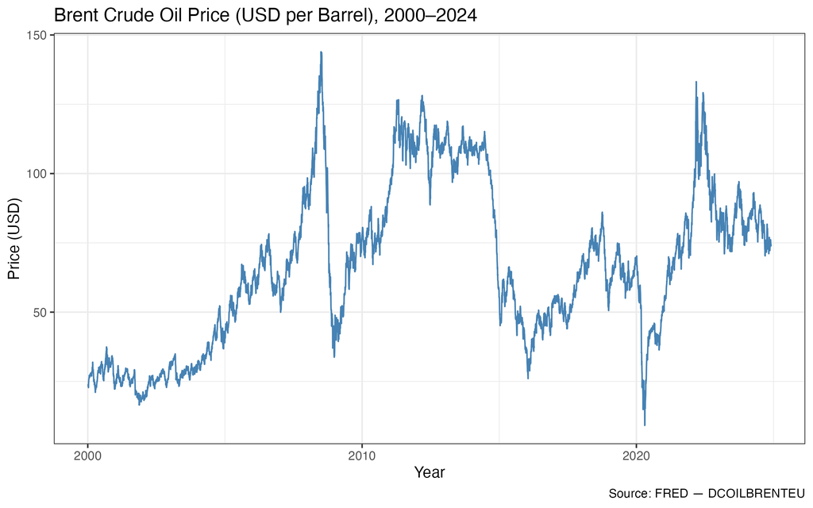

Figure 1

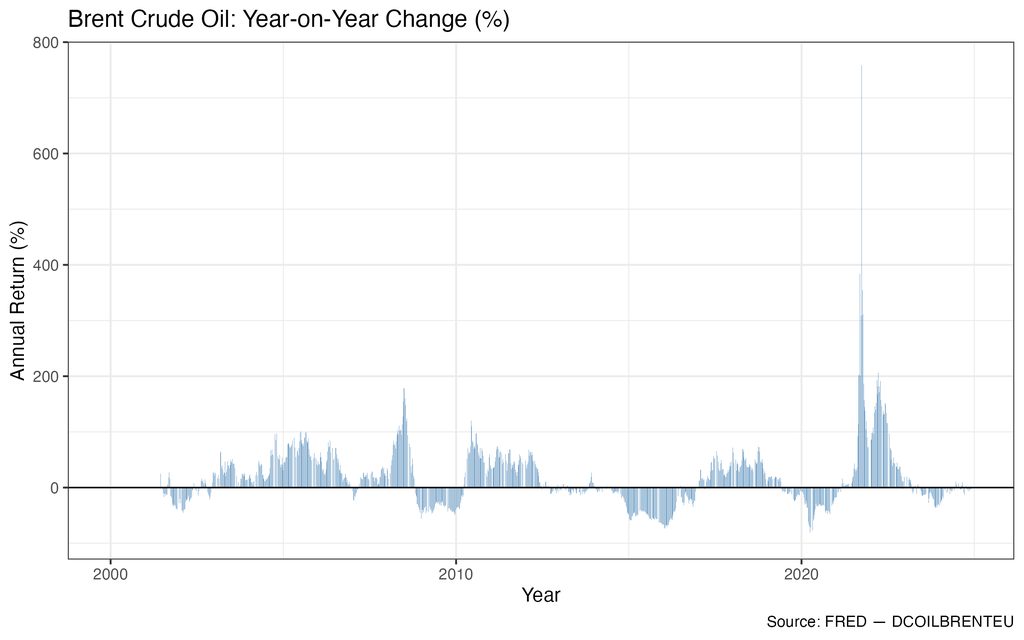

Figure 2

## How to Reproduce

1. Get a free API key at: https://fred.stlouisfed.org/docs/api/api_key.html
2. Replace `"YOUR_API_KEY_HERE"` in `analysis.R`
3. Create output folders: `dir.create("figures"); dir.create("data")`
4. Run `analysis.R` in RStudio with Ctrl+Shift+Enter